# AID - Trabajo Práctico Nro. I

Cargar directorio de trabajo:

```r
setwd("C:/Github/MScDataMiningUBA2015/AID")
```

Cargar librerías necesarias:

```r
require(xlsx)
require(tidyr)
require(dplyr)
require(ggplot2)
require(knitr)
```

## Ejercicio 1: Transformaciones de datos

Trabajo previo sobre el file recepcionistas: Escribir un nombre a ultimo campo, sino tira error.

Leer datos:

```r
recepcionistas<-read.xlsx("recepcionistas.xlsx",1)
```

Disponer datos en manera ordenada:

```r
df <- recepcionistas %>%
  rename(cord.juez1=cord.juez.1, cord.juez2=cord.juez.2) %>%
  gather(atributo, puntaje, -candidatos) %>%
  separate(atributo, into = c("atributo", "juez"), sep = "\\.")
kable(df)
```

| candidatos | atributo | juez | puntaje |
| --- | --- | --- | --- |
| Mariana | cord | juez1 | 80 |
| Maia | cord | juez1 | 80 |
| Sabrina | cord | juez1 | 90 |
| Daniela | cord | juez1 | 80 |
| Alejandra | cord | juez1 | 70 |
| Carla | cord | juez1 | 90 |
| Mariana | pres | juez1 | 90 |
| Maia | pres | juez1 | 90 |
| Sabrina | pres | juez1 | 60 |
| Daniela | pres | juez1 | 50 |
| Alejandra | pres | juez1 | 60 |
| Carla | pres | juez1 | 85 |
| Mariana | idiom | juez1 | 70 |
| Maia | idiom | juez1 | 60 |
| Sabrina | idiom | juez1 | 50 |
| Daniela | idiom | juez1 | 50 |
| Alejandra | idiom | juez1 | 50 |
| Carla | idiom | juez1 | 60 |
| Mariana | cord | juez2 | 60 |
| Maia | cord | juez2 | 65 |
| Sabrina | cord | juez2 | 70 |
| Daniela | cord | juez2 | 70 |
| Alejandra | cord | juez2 | 55 |
| Carla | cord | juez2 | 80 |
| Mariana | pres | juez2 | 78 |
| Maia | pres | juez2 | 90 |
| Sabrina | pres | juez2 | 60 |
| Daniela | pres | juez2 | 58 |
| Alejandra | pres | juez2 | 70 |
| Carla | pres | juez2 | 90 |
| Mariana | idiom | juez2 | 80 |
| Maia | idiom | juez2 | 65 |
| Sabrina | idiom | juez2 | 50 |
| Daniela | idiom | juez2 | 40 |
| Alejandra | idiom | juez2 | 65 |
| Carla | idiom | juez2 | 40 |

### a) Calcule el promedio por juez de cada una de las aspirantes

```r
a<- df %>%
  group_by(candidatos,juez)%>%
  summarise(promedio=mean(puntaje))
kable(a)
```

| candidatos | juez | promedio |
| --- | --- | --- |
| Alejandra | juez1 | 60.00000 |
| Alejandra | juez2 | 63.33333 |
| Carla | juez1 | 78.33333 |
| Carla | juez2 | 70.00000 |
| Daniela | juez1 | 60.00000 |
| Daniela | juez2 | 56.00000 |
| Maia | juez1 | 76.66667 |
| Maia | juez2 | 73.33333 |
| Mariana | juez1 | 80.00000 |
| Mariana | juez2 | 72.66667 |
| Sabrina | juez1 | 66.66667 |
| Sabrina | juez2 | 60.00000 |

### b) Calcule el promedio de cada una de las aspirantes tomando en cuenta todos los rubros y ambos jueces

```r
b<- df %>%
  group_by(candidatos) %>%
  summarise(promedio=mean(puntaje))
kable(b)
```

| candidatos | promedio |
| --- | --- |
| Alejandra | 61.66667 |
| Carla | 74.16667 |
| Daniela | 58.00000 |
| Maia | 75.00000 |
| Mariana | 76.33333 |
| Sabrina | 63.33333 |

### c) Transformar las puntuaciones observadas de modo tal que cada una seis variables tenga media 0 y dispersión 1.

Esto permite observar variación entre las candidatas dentro de un mismo atributo y un mismo juez.

```r
c<- df %>%
  group_by(juez,atributo) %>%
  mutate(est=(puntaje-mean(puntaje))/sd(puntaje)) %>%
  ungroup()
kable(c)
```

| candidatos | atributo | juez | puntaje | est |
| --- | --- | --- | --- | --- |
| Mariana | cord | juez1 | 80 | -0.2214037 |
| Maia | cord | juez1 | 80 | -0.2214037 |
| Sabrina | cord | juez1 | 90 | 1.1070186 |
| Daniela | cord | juez1 | 80 | -0.2214037 |
| Alejandra | cord | juez1 | 70 | -1.5498260 |
| Carla | cord | juez1 | 90 | 1.1070186 |
| Mariana | pres | juez1 | 90 | 0.9821237 |
| Maia | pres | juez1 | 90 | 0.9821237 |
| Sabrina | pres | juez1 | 60 | -0.7015169 |
| Daniela | pres | juez1 | 50 | -1.2627304 |
| Alejandra | pres | juez1 | 60 | -0.7015169 |
| Carla | pres | juez1 | 85 | 0.7015169 |
| Mariana | idiom | juez1 | 70 | 1.6329932 |
| Maia | idiom | juez1 | 60 | 0.4082483 |
| Sabrina | idiom | juez1 | 50 | -0.8164966 |
| Daniela | idiom | juez1 | 50 | -0.8164966 |
| Alejandra | idiom | juez1 | 50 | -0.8164966 |
| Carla | idiom | juez1 | 60 | 0.4082483 |
| Mariana | cord | juez2 | 60 | -0.7613870 |
| Maia | cord | juez2 | 65 | -0.1903467 |
| Sabrina | cord | juez2 | 70 | 0.3806935 |
| Daniela | cord | juez2 | 70 | 0.3806935 |
| Alejandra | cord | juez2 | 55 | -1.3324272 |
| Carla | cord | juez2 | 80 | 1.5227740 |
| Mariana | pres | juez2 | 78 | 0.2598796 |
| Maia | pres | juez2 | 90 | 1.1103946 |
| Sabrina | pres | juez2 | 60 | -1.0158929 |
| Daniela | pres | juez2 | 58 | -1.1576454 |
| Alejandra | pres | juez2 | 70 | -0.3071304 |
| Carla | pres | juez2 | 90 | 1.1103946 |
| Mariana | idiom | juez2 | 80 | 1.4564382 |
| Maia | idiom | juez2 | 65 | 0.5201565 |
| Sabrina | idiom | juez2 | 50 | -0.4161252 |
| Daniela | idiom | juez2 | 40 | -1.0403130 |
| Alejandra | idiom | juez2 | 65 | 0.5201565 |
| Carla | idiom | juez2 | 40 | -1.0403130 |

### d) Transformar las puntuaciones de modo tal que cada candidata tenga para cada juez media 0 y dispersión 1.

Esto permite observar la variación entre los atributos de una misma candidata y un mismo juez

```r
d<-df %>%
  group_by(juez,candidatos) %>%
  mutate(est=(puntaje-mean(puntaje))/sd(puntaje))%>%
  ungroup()
kable(d)
```

| candidatos | atributo | juez | puntaje | est |
| --- | --- | --- | --- | --- |
| Mariana | cord | juez1 | 80 | 0.0000000 |
| Maia | cord | juez1 | 80 | 0.2182179 |
| Sabrina | cord | juez1 | 90 | 1.1208971 |
| Daniela | cord | juez1 | 80 | 1.1547005 |
| Alejandra | cord | juez1 | 70 | 1.0000000 |
| Carla | cord | juez1 | 90 | 0.7258662 |
| Mariana | pres | juez1 | 90 | 1.0000000 |
| Maia | pres | juez1 | 90 | 0.8728716 |
| Sabrina | pres | juez1 | 60 | -0.3202563 |
| Daniela | pres | juez1 | 50 | -0.5773503 |
| Alejandra | pres | juez1 | 60 | 0.0000000 |
| Carla | pres | juez1 | 85 | 0.4147807 |
| Mariana | idiom | juez1 | 70 | -1.0000000 |
| Maia | idiom | juez1 | 60 | -1.0910895 |
| Sabrina | idiom | juez1 | 50 | -0.8006408 |
| Daniela | idiom | juez1 | 50 | -0.5773503 |
| Alejandra | idiom | juez1 | 50 | -1.0000000 |
| Carla | idiom | juez1 | 60 | -1.1406469 |
| Mariana | cord | juez2 | 60 | -1.1499323 |
| Maia | cord | juez2 | 65 | -0.5773503 |
| Sabrina | cord | juez2 | 70 | 1.0000000 |
| Daniela | cord | juez2 | 70 | 0.9271726 |
| Alejandra | cord | juez2 | 55 | -1.0910895 |
| Carla | cord | juez2 | 80 | 0.3779645 |
| Mariana | pres | juez2 | 78 | 0.4841820 |
| Maia | pres | juez2 | 90 | 1.1547005 |
| Sabrina | pres | juez2 | 60 | 0.0000000 |
| Daniela | pres | juez2 | 58 | 0.1324532 |
| Alejandra | pres | juez2 | 70 | 0.8728716 |
| Carla | pres | juez2 | 90 | 0.7559289 |
| Mariana | idiom | juez2 | 80 | 0.6657503 |
| Maia | idiom | juez2 | 65 | -0.5773503 |
| Sabrina | idiom | juez2 | 50 | -1.0000000 |
| Daniela | idiom | juez2 | 40 | -1.0596259 |
| Alejandra | idiom | juez2 | 65 | 0.2182179 |
| Carla | idiom | juez2 | 40 | -1.1338934 |

### e) Grafique los perfiles multivariados de cada una de las candidatas para ambas transformaciones.

#### 1) Variación entre las candidatas dentro de un mismo juez y un mismo atributo. Probamos con dos visualizaciones, la primera permite comparar mejor las diferencias entre jueces, la segunda, permite ver el perfil de atributos de cada candidata.

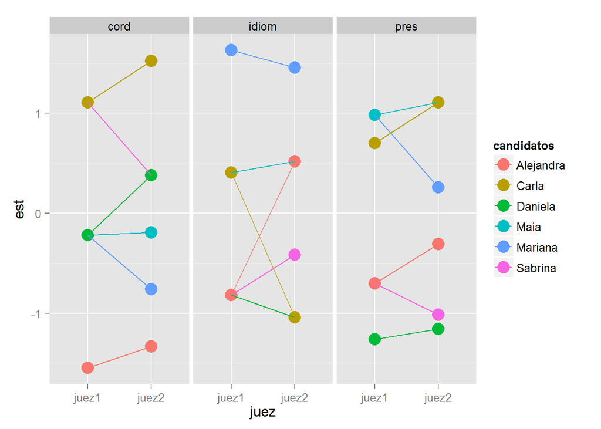

```r
e1<-ggplot(c, aes(x=juez, y=est, group=candidatos, color=candidatos))+
  geom_point(size=5)+
  geom_line()+
  facet_grid(.~atributo)

print(e1)
```

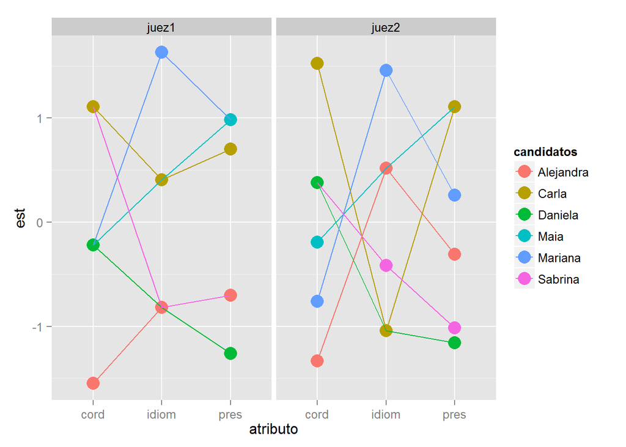

```r
e2<-ggplot(c, aes(x=atributo, y=est, group=candidatos, color=candidatos))+
  geom_point(size=5)+
  geom_line()+
  facet_grid(.~juez)

print(e2)
```

Conclusiones:

Si intentamos hacer un ranking de candidatas para cada atributo:

Si hay alguna preferencia de los jueces por alguna candidata, podemos decir que el juez dos prefiere más a Alejandra que el juez 1. Mientras que el juez uno prefiere más a Mariana que el juez 2.

#### 2) Variación entre los atributos de una misma candidata y un mismo juez. La primera visualización permite ver las diferencias entre ambos jueces, la segunda permite ver cómo evaluló cada juez en general con respecto a cada atributo.

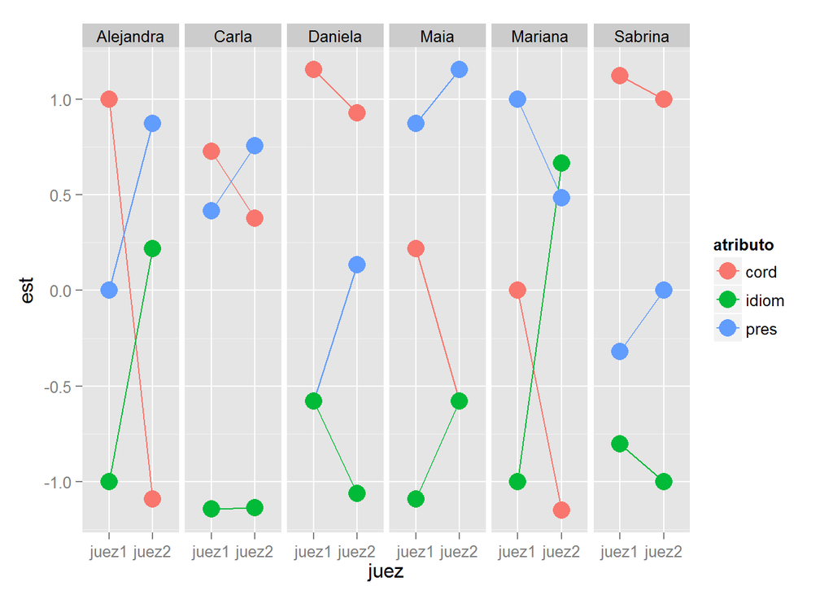

```r
e3<-ggplot(d, aes(x=juez, y=est, group=atributo, color=atributo))+
  geom_line()+
  geom_point(size=5)+
  facet_grid(.~candidatos)

print(e3)
```

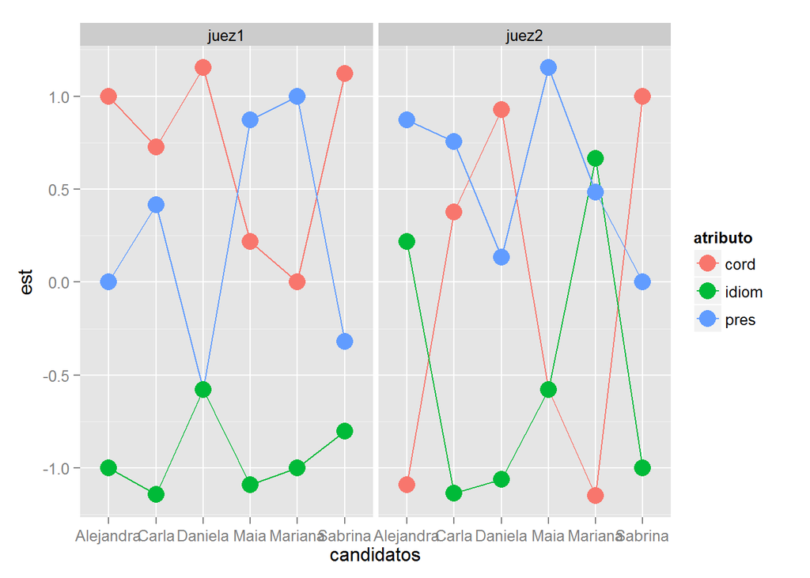

```r
e4<-ggplot(d, aes(x=candidatos, y=est, group=atributo, color=atributo))+
  geom_line()+
  geom_point(size=5)+
  facet_grid(.~juez)

print(e4)
```

El juez 1 tiene a ser más exigente en idiomas que en coordinación, y el juez 2 suele puntuar mejor en presencia que en los otros atributos.